# GFA - Data Visualization Exercise

Jake Rozran

2022-06-24

## Introduction

Let’s take a look at the MPG dataset. This dataset contains a subset of the fuel economy data that the EPA makes available on http://fueleconomy.gov. It contains only models which had a new release every year between 1999 and 2008 - this was used as a proxy for the popularity of the car.

## Data

To access the data, please click the option that works for you below:

- [Microsoft Excel](https://drive.google.com/file/d/196FfUaUGOm4gWbOi_K7VR_y3wmOPC0PM/view?usp=sharing) (download the spreadsheet)
- [Google Sheets](https://docs.google.com/spreadsheets/d/10Gyloc1RvPy-URF6IH5hZZq0hiqexPyofAGmbRUuu2w/edit?usp=sharing) (copy the sheet to your own drive)

## Questions to Answer

### 1. Research

- Explore the data to see what’s in there
- (Optional) What is the range, median, and mean for displacement (`disp`), year, # of engine cylinders (`cyl`), city mpg (`cty`), and highway mpg (`hwy`)?

| manufacturer | model | displ | year | cyl | trans | drv | cty | hwy | fl | class |
| --- | --- | --- | --- | --- | --- | --- | --- | --- | --- | --- |
| audi | a4 | 1.8 | 1999 | 4 | auto(l5) | f | 18 | 29 | p | compact |
| audi | a4 | 1.8 | 1999 | 4 | manual(m5) | f | 21 | 29 | p | compact |
| audi | a4 | 2.0 | 2008 | 4 | manual(m6) | f | 20 | 31 | p | compact |
| audi | a4 | 2.0 | 2008 | 4 | auto(av) | f | 21 | 30 | p | compact |
| audi | a4 | 2.8 | 1999 | 6 | auto(l5) | f | 16 | 26 | p | compact |
| audi | a4 | 2.8 | 1999 | 6 | manual(m5) | f | 18 | 26 | p | compact |

### 2. Edit

- Pick a car manufacturer
- How many models does they have that have been around from 1999 - 2008?
- Does one model have better or worse gas mileage than the others?

Example:

- Pick a car manufacturer: *ford*
- How many models does they have? *4*
- Does one model have better or worse gas mileage than the others? *The mustang,* *which is the only car here, has slightly better gas mileage than the* *trucks/suvs.*

### 3. Plot

Bar Chart:

1. Choose a model, make a bar chart that shows both the `cty` and `hwy` mpg over time
2. Does that model have multiple `cyl` options? If so, plot those in separate panels (aka facets)

Scatter Plot:

1. Filter the data for 2008 only; make a scatter plot that has displacement (`displ`) on the y-axis and highway gas mileage (`hwy`) on the x-axis.

Example:

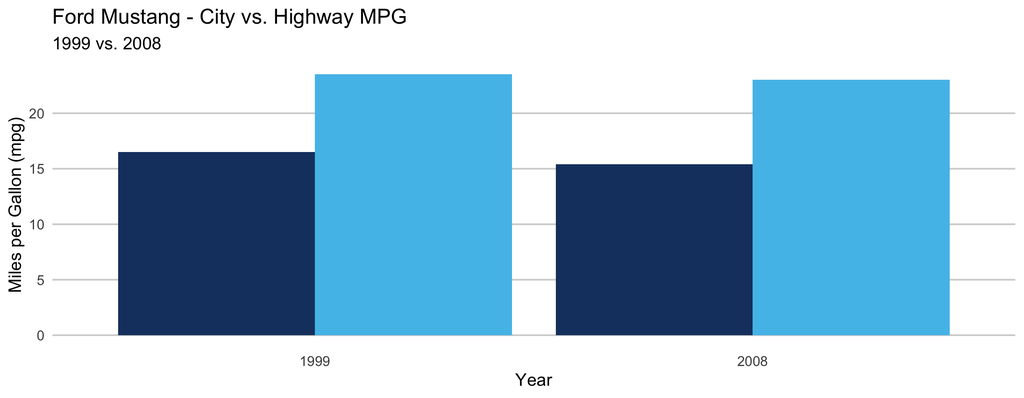

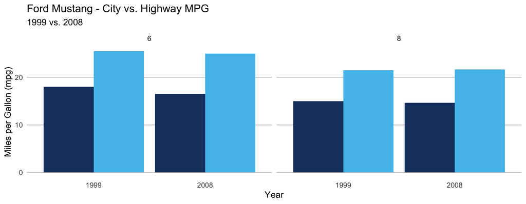

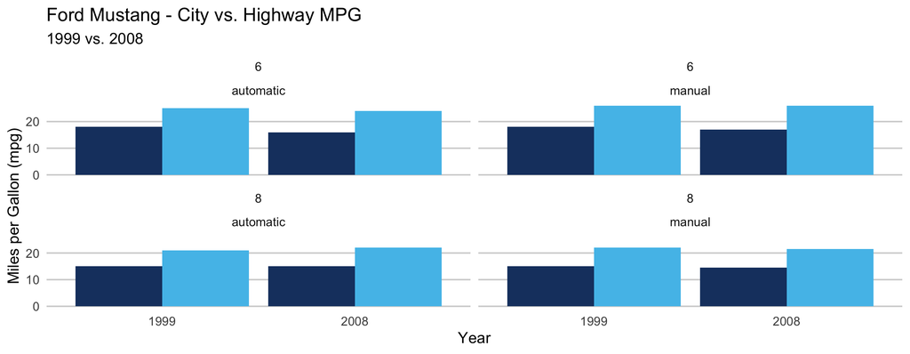

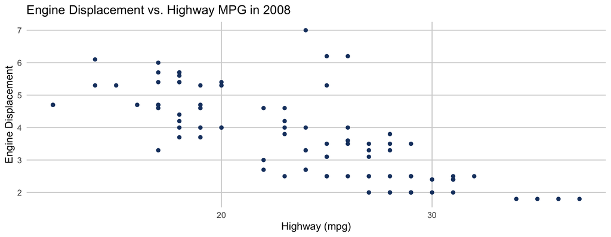

### 4. Review

- Does anything stick out in your bar charts? How about in the scatter plot?
- If so, can you find an explanation for those things?